# Lasso, Ridge, RF with Adult Data

Daniel_Kim

2020-04-04

```r
library(tidyverse)
```

## 9.1 glmnet 함수룰 통한 라쏘 모형, 능형회귀, 변수 선택

### 9.1.1 라쏘, 능형모형, 일라스틱 넷, glmnet

- GLM 모형은 다음 수식을 풀어서 MLE(Maximum Likelihood Estimator, 최대우도추정치) $\hat{\beta}$을 찾는다.

$$\displaystyle \lim_{\beta} \frac{1}{n} \left[ -l(y_{i}, x_{i} \beta) \right]$$

- $-l(y_{i}, x_{i}\beta)$는 관측치 $i$의 로그우도 값이다
- 독립된 변수들에 대한 확률의 곱에 대한 계산을 편리하게 하기 위해 로그를 씌워 더하기 형태로 변환한다.(곱하기에 로그를 씌우면 더하기가 되므로…)
- 편미분을 도입하여 가장 최소가 되는 지점을 찾는다. 여기서 $y_{i}$와 $x_{i}$는 고정되어진 값이고 $\beta$에 대한 편미분을 통해 전체 값이 최소가 되는 $\beta$를 찾는 것이다.
- GLM은 모든 x 변수에 대한 모수를 계산해주는데, 모수가 너무 많아지므로 모형의 해석 가능성이 떨어지고 모형의 예측능력이 떨어진다는 문제가 있다. 이를 위해 $boot::cv.glm()$을 사용해 유의미한 변수를 선택한다.
- 모형이 복잡도를 감안해주는 또 다른 방법은 모형 복잡도에 대한 벌점을 추가하는 것이다. 즉 다음 함수를 최소화하는 것이다.

$$\displaystyle \lim_{\beta} \left( -우도(\beta, X, Y) + 모형의 \ 복잡도(\beta) \right)$$

- 이러한 방법은 penalized maximum likelihood라고 하고 벌점을 regularization term이라고 한다.
- LASSO regression은 모형의 복잡도를 $L1-norm : ||\beta|| = |\beta_{1}| + ... + |\beta_{p}|$를 사용한다.

$$\displaystyle \lim_{\beta} \left[ -l(y_{i}, x_{i} \beta) + \lambda \|\beta||\ \right]$$

- Ridge regressio은 모형의 복잡도를 $L2-norm : ||\beta||^{2} = \beta_{1}^{2} + ... + \beta_{p}^{2}$를 사용한다.

$$\displaystyle \lim_{\beta} \left[ -l(y_{i}, x_{i} \beta) + \lambda \|\beta||^{2}\ \right]$$

- Elasticnet은 Lasso 모형과 Ridge모형을 일반화한 다음의 모형을 푼다.

$$\displaystyle \lim_{\beta} \left[ -l(y_{i}, x_{i} \beta) + \lambda (1- \alpha) \|\beta||^{2}\ + \alpha ||\beta|| \right]$$

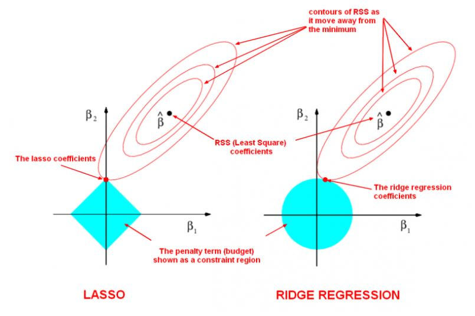

Lasso and Ridge

- $\lambda = 0$이면 MLE의 해가 되고, $\lambda$가 커질수록 regualarized model이 된다.
- Ridge의 경우에는 추정모수의 값을 원점에 가깝게 만들어주고, Lasso일 경우에는 더 많은 추정모수 값을 0으로 만들어준다. 즉, Lasso의 경우에는 더 많은 추정모수 값을 0으로 만들어준다. 즉 Lasso는 실질적인 변수선택의 방법으로 사용될 수 있다.

### 9.1.2 glmnet과 모형행렬

- `glmnet()` 함수는 모형행렬을 수동으로 만들어주어야 한다. 이는 model.matrix() 함수를 사용하면 된다. 절편항을 필요하지 않으므로 ’-1’을 formula에 지정한다.

```r
adult <- read.csv("adult.data", header = F, strip.white = T)

names(adult) <- c("age", "workclass", "fnlwgt", "education", "education_num",
                  "marital_status", "occupation", "relationship", "race", "sex",
                  "capital_gain", "capital_loss", "hours_per_week", "native_country",
                  "wage")
adult %>% head()
```

|  | age | workclass | fnlwgt | education | education_num | marital_status | occupation | relationship | race | sex | capital_gain | capital_loss | hours_per_week | native_country | wage |
| --- | --- | --- | --- | --- | --- | --- | --- | --- | --- | --- | --- | --- | --- | --- | --- |
| 1 | 39 | State-gov | 77516 | Bachelors | 13 | Never-married | Adm-clerical | Not-in-family | White | Male | 2174 | 0 | 40 | United-States | <=50K |
| 2 | 50 | Self-emp-not-inc | 83311 | Bachelors | 13 | Married-civ-spouse | Exec-managerial | Husband | White | Male | 0 | 0 | 13 | United-States | <=50K |
| 3 | 38 | Private | 215646 | HS-grad | 9 | Divorced | Handlers-cleaners | Not-in-family | White | Male | 0 | 0 | 40 | United-States | <=50K |
| 4 | 53 | Private | 234721 | 11th | 7 | Married-civ-spouse | Handlers-cleaners | Husband | Black | Male | 0 | 0 | 40 | United-States | <=50K |
| 5 | 28 | Private | 338409 | Bachelors | 13 | Married-civ-spouse | Prof-specialty | Wife | Black | Female | 0 | 0 | 40 | Cuba | <=50K |
| 6 | 37 | Private | 284582 | Masters | 14 | Married-civ-spouse | Exec-managerial | Wife | White | Female | 0 | 0 | 40 | United-States | <=50K |

```r
binomial_deviance <- function(y_obs, yhat) {
  epsilon = 0.0001
  yhat = ifelse(yhat < epsilon, epsilon, yhat)
  yhat = ifelse(yhat > 1- epsilon, 1-epsilon, yhat)
  a = ifelse(y_obs == 0, 0, y_obs * log(y_obs/yhat))
  b = ifelse(y_obs==1, 0, (1-y_obs) * log((1-y_obs)/(1-yhat)))
  return((2*sum(a+b)))
}

set.seed(2020)
n <- nrow(adult)
idx <- 1:n
training_idx <- sample(idx, n * .6)

idx <- setdiff(idx, training_idx) # reflesh idx...
validate_idx <- sample(idx, n * .2)
test_idx <- setdiff(idx, validate_idx)

# length(training_idx)
# length(validate_idx)
# length(test_idx)

training <- adult[training_idx, ]
validation <- adult[validate_idx, ]
test <- adult[test_idx, ]
```

```r
xx <- model.matrix(wage ~ .-1, adult)
x <- xx[training_idx, ]
y <- ifelse(training$wage == '>50K', 1, 0)

dim(x)
```

```
[1] 19536   101
```

```r
library(glmnet)
ad_glmnet_fit <- glmnet(x, y)
```

```r
library(coefplot)
coefpath(ad_glmnet_fit)
```

[interactive chart not shown]

```r
plot(ad_glmnet_fit)
```

[output not shown]

```r
ad_glmnet_fit
```

[output not shown]

```r
coef(ad_glmnet_fit, s = c(0.1741000, 0.1317000))
```

[output not shown]

- $Df = 1$일때 모형은 다음과 같다.

$$eta = 0.22338157 +0.03406252 \times marital_statusMarried-civ-spouse$$

- $Df = 2$일때 모형은 다음과 같다.

$$eta = 0.166246866 +0.118320874 \times marital-statusMarried-civ-spouse + 0.001821285 \times education-num$$

### 9.1.3 자동 모형 선택, cv.glmnet

- glmnet() 함수의 결과는 다양한 lambda값에 대한 다른 모형들이다.
- 자동으로 모형을 선택하기 위해서는 교차검증을 수행하는 cv.glmnet() 함수를 사용한다.

```r
ad_cvfit <- cv.glmnet(x, y, family = 'binomial')
plot(ad_cvfit)
```

[output not shown]

```r
log(ad_cvfit$lambda.min)
```

```r
log(ad_cvfit$lambda.1se)
```

- 최적의 $\lambda$ 값에서 모수의 값들을 보려면 s = option에 lambda.min, lambda.1se을 설정하여 주면 된다.

```r
coef(ad_cvfit, s = ad_cvfit$lambda.1se)
```

```r
coef(ad_cvfit, s = ad_cvfit$lambda.min)
```

```r
which(coef(ad_cvfit, s = 'lambda.min') > 0) %>% length()
```

```r
which(coef(ad_cvfit, s = 'lambda.1se') > 0) %>% length()
```

[output not shown]

- glmnet() 함수는 default로 $\alpha = 1$, 즉 Lasso를 선택한다.

```r
set.seed(2020)
foldid <- sample(1:10, size = length(y), replace = T)

cv1 <- cv.glmnet(x, y, foldid = foldid, alpha = 1, family = 'binomial')
```

```r
cv.5 <- cv.glmnet(x, y, foldid = foldid, alpha = .5, family = 'binomial')
```

```r
cv0 <- cv.glmnet(x, y, foldid = foldid, alpha = 0)
```

```r
par(mfrow = c(2, 2))
plot(cv1, main = 'Alpha = 1.0')
plot(cv.5, main = 'Alpha = .5')
```

```r
plot(cv0, main = 'Alpha = 0' )

plot(log(cv1$lambda), cv1$cvm, pch = 19, col='red',
     xlab = 'log(Lambda)', ylab = cv1$name, main = 'alpha = 1.0')
```

```r
points(log(cv.5$lambda), cv.5$cvm, pch = 19, col = 'grey')
points(log(cv0$lambda), cv0$cvm, pch = 19, col = 'blue')
```

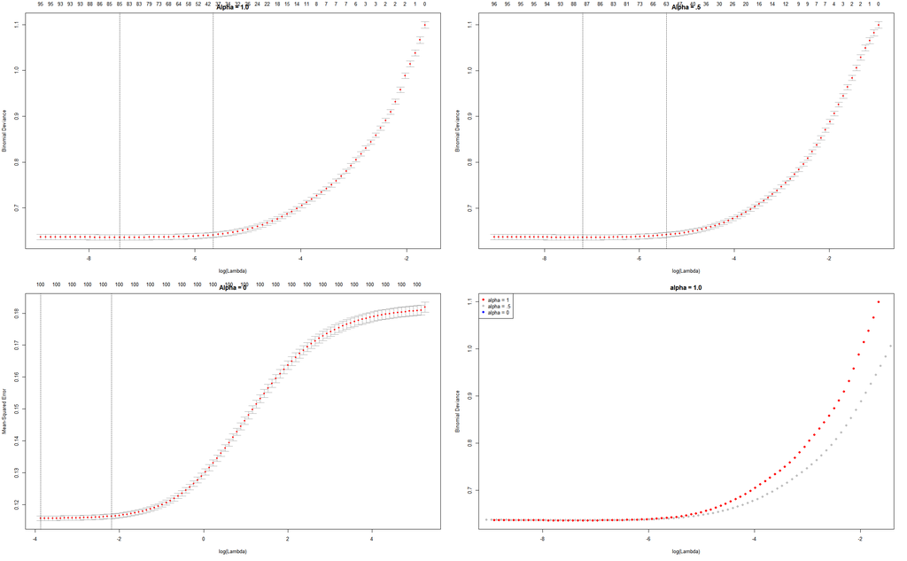

```r
legend('topleft', legend = c('alpha = 1', 'alpha = .5', 'alpha = 0'),
       pch = 19, col = c('red', 'grey', 'blue'))
```

### 9.1.5 예측, predict.glmnet

```r
predict(ad_cvfit, s = 'lambda.1se', newx = x[1:5, ], type = 'response')
```

### 9.1.6 모형평가

- ROC graph

```r
y_obs <- ifelse(validation$wage == '>50K', 1, 0)
yhat_glmnet <- predict(ad_cvfit, s = 'lambda.1se', newx = xx[validate_idx, ],
                      type ='response')

yhat_glmnet <- yhat_glmnet[, 1]

binomial_deviance(y_obs, yhat_glmnet)
```

```
[1] 4216.782
```

```r
library(ROCR)
pred_glmnet <- prediction(yhat_glmnet, y_obs)
perf_glment <- performance(pred_glmnet, measure = 'tpr', x.measure = 'fpr')

plot(perf_glment, col = 'blue', main = 'ROC Curve')
abline(0, 1)
```

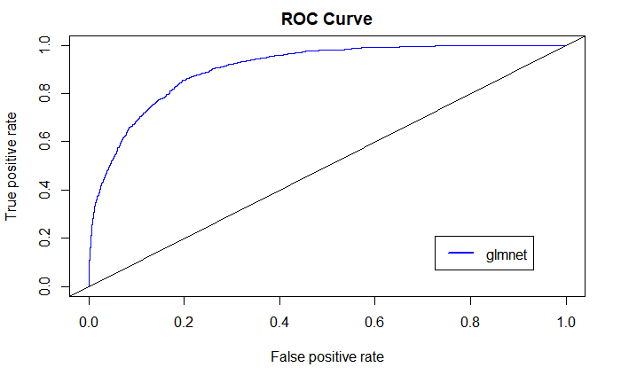

```r
legend('bottomright', inset = .1,
       legend = c('glmnet'),
       col = c('blue'),
       lty = 1,
       lwd = 2)
```

- AUC

```r
performance(pred_glmnet, 'auc')@y.values[[1]]
```

[output not shown]

## 9.2 나무 모형

### 9.2.1. 나무모형이란?

- 먼저 그리디(greedy)한 방법으로 재귀적 이항나무(resurcive binary tree splitting)을 행하고,
- 가지치기(prunning)를 하여 여러 모형을 생성한 후,
- 내부적으로 K-fold CV를 행하여 최적의 모형을 선택한다.

$$G = p(1 - p)$$

- 만약 성공과 실패가 반반씩 있다면 $G = 1/4$을 가지는데 이것이 지니지수의 최재값이다.

### 9.2.2 나무 모형 적합

```r
library(rpart)
cvr_tr <- rpart(wage ~ ., data = training)
cvr_tr
```

```
n= 19536

node), split, n, loss, yval, (yprob)
      * denotes terminal node

 1) root 19536 4670 <=50K (0.760954136 0.239045864)
   2) relationship=Not-in-family,Other-relative,Own-child,Unmarried 10677  680 <=50K (0.936311698 0.063688302)
     4) capital_gain< 7565.5 10503  508 <=50K (0.951632867 0.048367133) *
     5) capital_gain>=7565.5 174    2 >50K (0.011494253 0.988505747) *
   3) relationship=Husband,Wife 8859 3990 <=50K (0.549610566 0.450389434)
     6) occupation=?,Adm-clerical,Armed-Forces,Craft-repair,Farming-fishing,Handlers-cleaners,Machine-op-inspct,Other-service,Priv-house-serv,Transport-moving 4706 1348 <=50K (0.713557161 0.286442839)
      12) capital_gain< 5095.5 4486 1134 <=50K (0.747213553 0.252786447) *
      13) capital_gain>=5095.5 220    6 >50K (0.027272727 0.972727273) *
     7) occupation=Exec-managerial,Prof-specialty,Protective-serv,Sales,Tech-support 4153 1511 >50K (0.363833373 0.636166627)
      14) capital_gain< 5095.5 3625 1508 >50K (0.416000000 0.584000000)
        28) education_num< 11.5 1631  707 <=50K (0.566523605 0.433476395)
          56) capital_loss< 1846 1556  637 <=50K (0.590616967 0.409383033) *
          57) capital_loss>=1846 75    5 >50K (0.066666667 0.933333333) *
        29) education_num>=11.5 1994  584 >50K (0.292878636 0.707121364) *
      15) capital_gain>=5095.5 528    3 >50K (0.005681818 0.994318182) *
```

```r
printcp(cvr_tr)
```

```
Classification tree:
rpart(formula = wage ~ ., data = training)

Variables actually used in tree construction:
[1] capital_gain  capital_loss  education_num occupation    relationship

Root node error: 4670/19536 = 0.23905

n= 19536

        CP nsplit rel error  xerror     xstd
1 0.121092      0   1.00000 1.00000 0.012765
2 0.044540      2   0.75782 0.76510 0.011570
3 0.036403      3   0.71328 0.71370 0.011259
4 0.023233      4   0.67687 0.67816 0.011031
5 0.013919      6   0.63041 0.64090 0.010780
6 0.010000      7   0.61649 0.63662 0.010751
```

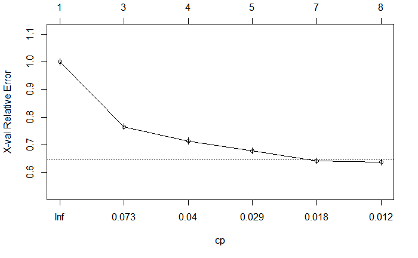

```r
plotcp(cvr_tr)
```

- error가 가장 낮은 split 개수를 선택한다.

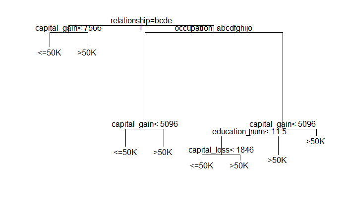

```r
opar <- par(mfrow = c(1, 1), xpd = NA)
ptree <- prune(cvr_tr,
             cp=cvr_tr$cptable[which.min(cvr_tr$cptable[,"xerror"]),"CP"])

plot(ptree)
text(ptree)
```